# Reproducible Research: Peer Assessment 1

## Loading and preprocessing the data

1.Code for loading the required libraries and the data.

```r
## Loading libraries
library(readr)
library(plyr)
library(dplyr)
library(Hmisc)
## Reading the data
activity <- read_csv("activity.zip")
```

2.Processing the data(including all the procesing for further analyses)

```r
a1 <- tapply(activity$steps, activity$date, sum, na.rm = TRUE)
a2 <- tapply(activity$steps, activity$interval, mean, na.rm = TRUE)
```

## What is mean total number of steps taken per day?

1.Following is the histogram for the total number of steps taken everyday

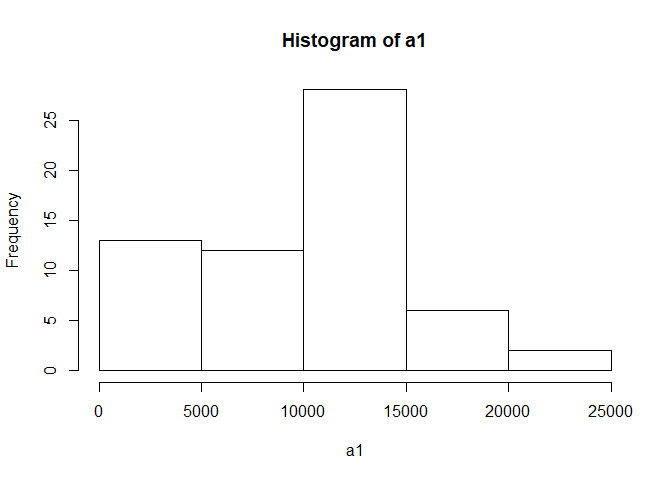

```r
hist(a1)
```

The histogram shows the frequency of the total number of steps taken everyday  
2.Followng is the mean and median of the total number of steps taken everyday

```r
mean(a1)
```

```
## [1] 9354.23
```

```r
median(a1)
```

```
## [1] 10395
```

## What is the average daily activity pattern?

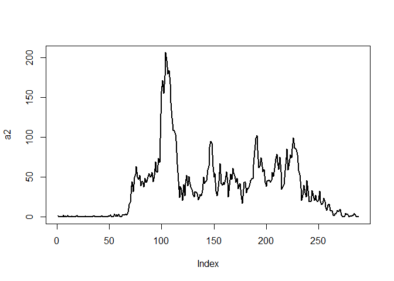

```r
plot(a2, type = "l", lwd = 2)
```

2.The 5-minute interval which has highest avergave on all days is

```r
which.max(a2)
```

```
## 835
## 104
```

## Imputing missing values

1.The total number of missing values in the dataset are:

```r
sum(is.na(activity$steps))
```

```
## [1] 2304
```

2.The missing values are replaced with the mean of the corresponding 5-minute interval

```r
activity2 <- activity %>%
group_by(interval) %>%
mutate_each(funs(replace(., which(is.na(.)), mean(., na.rm=TRUE))),
+                   starts_with('steps'))
```

3.A new dataset called activity2 is created after imputing the missing values

4.Histogram of the total number of steps taken everyday after imputing the values is as follows:

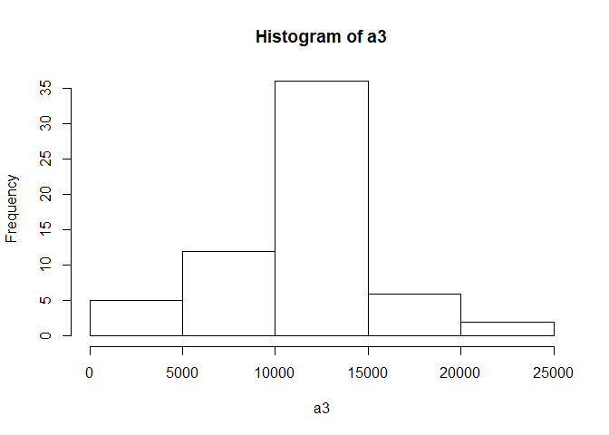

```r
a3 <- tapply(activity2$steps, activity2$date, sum, na.rm = TRUE)
hist(a3)
```

The mean and median of the total steps taken everyday in the new dataset is as follows:

```r
mean(a3)
```

```
## [1] 10766.19
```

```r
median(a3)
```

```
## [1] 10766.19
```

```r
weekday1 <- c("Monday", "Tuesday", "Wednesday", "Thursday", "Friday")
activity2 <- mutate(activity2, holiday = factor((weekdays(date) %in% weekday1),
                                                levels=c(FALSE, TRUE), labels=c('weekend', 'weekday') ))
```

2.Plotting the average of the steps taken in each 5-minute interval according to the factor variable holiday:

```r
act2 <- group_by(activity2, holiday, interval) %>% summarise(steps = mean(steps))
```

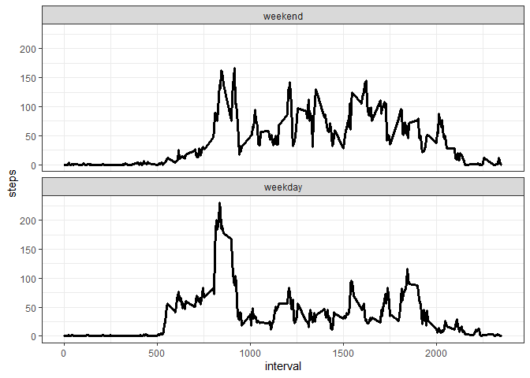

```r
ggplot(na.omit(act2), aes(x = interval, y = steps)) + geom_line(lwd=1.2) + facet_wrap(.~holiday, nrow = 2) + theme_bw()
```